# Tugas Pertemuan 5

Abie

2025-09-28

```r
library("forecast")
library("graphics")
library("TTR")
library("TSA")
library("rio")
library("ggplot2")
```

# Data

```r
dataaqi<-read.csv("C:\\Users\\Abie\\OneDrive\\Documents\\5\\mpdw\\dataudarajkt.csv")
dataaqi<-dataaqi[1:125,c(1,4)] # Periode 1 sampai 125
dataaqi$periode<-seq(125)
dataaqi<-dataaqi[,c("periode","tanggal","pm10")]
head(dataaqi)
```

```
##   periode    tanggal pm10
## 1       1 2023-10-18   64
## 2       2 2023-10-19   65
## 3       3 2023-10-20   62
## 4       4 2023-10-21   63
## 5       5 2023-10-22   60
## 6       6 2023-10-23   62
```

# Plot Data Time Series

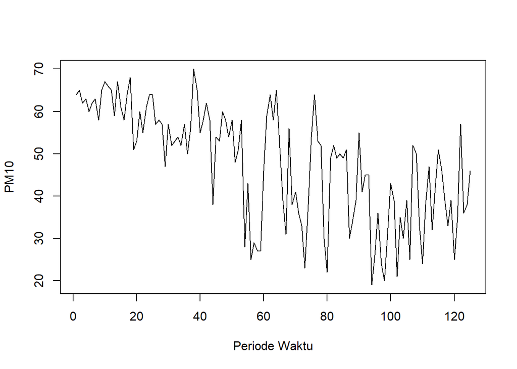

```r
dataaqi.ts<-ts(dataaqi$pm10)
ts.plot(dataaqi.ts, xlab="Periode Waktu", ylab="PM10")
```

Dari plot di atas, secara eksploratif terlihat bahwa nilai tengahnya tidak menetap pada satu nilai (cenderung tren) dan amplitudo fluktuasinya juga tidak konstan, sehingga dugaan awalnya adalah data tidak stasioner baik dalam rataan maupun ragam. Namun, untuk memastikannya, perlu dilakukan beberapa pemeriksaan lebih lanjut

# Pemeriksaan Stasioneritas Data

## Stasioneritas Rataan

### Plot ACF

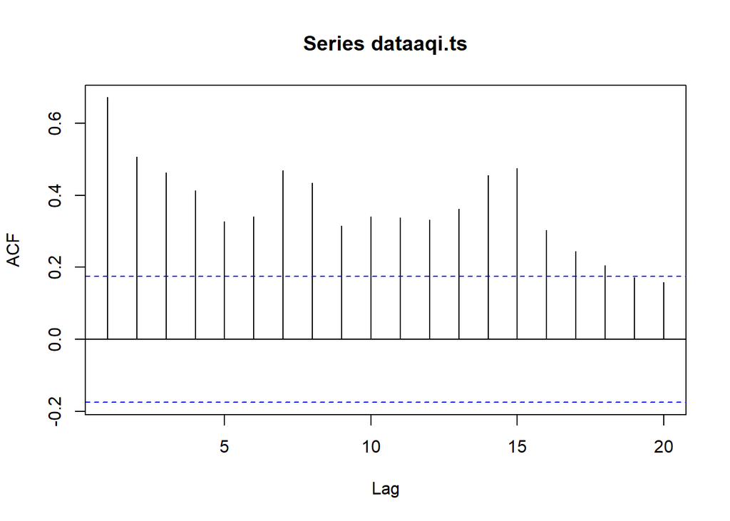

```r
acf(dataaqi.ts)
```

### Uji ADF

```r
tseries::adf.test(dataaqi.ts)
```

```
##
##  Augmented Dickey-Fuller Test
##
## data:  dataaqi.ts
## Dickey-Fuller = -5.2858, Lag order = 4, p-value = 0.01
## alternative hypothesis: stationary
```

Berdasarkan uji ADF tersebut, didapat p-value sebesar 0.01 yang lebih kecil dari taraf nyata 5% sehingga tolak H0 dan menandakan bahwa data stasioner dalam rataan. Hasil uji ini kontradiktif dengan eksplorasi pada plot time series dan ACF yang sudah dilakukan. Oleh karena itu, data akan diperlakukan dengan 2 opsi berbeda, didifferencing dan tidak. Hal ini hanya untuk membandingkan bagaimana data akhir nantinya

## Stasioneritas Ragam

### Plot Box-Cox

```r
library(MASS)
bc <- boxcox(
  dataaqi.ts ~ dataaqi$periode,
  lambda = seq(-1, 4, by = 0.01)
)
```

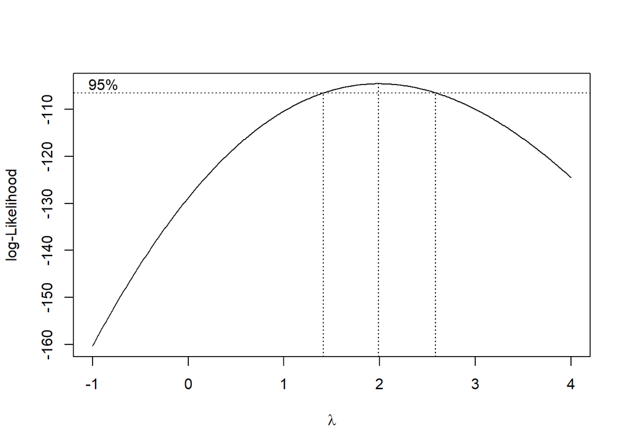

```r
lambda <- bc$x[which.max(bc$y)]
lambda
```

```
## [1] 1.99
```

```r
# Selang kepercayaan 95% untuk lambda
ci_lambda <- bc$x[bc$y > max(bc$y) - 0.5 * qchisq(0.95, 1)]

# Batas bawah dan batas atas
ci_lower <- min(ci_lambda)
ci_upper <- max(ci_lambda)

c(Batas_Bawah = ci_lower, Batas_Atas = ci_upper)
```

```
## Batas_Bawah  Batas_Atas
##        1.42        2.58
```

Hasil uji Box–Cox menunjukkan bahwa nilai λ optimum adalah 1.99 dengan interval kepercayaan 95% sebesar (1,42–2,58). Karena selang tersebut tidak memuat nilai λ = 1, maka dapat disimpulkan bahwa data tidak stasioner dalam ragam sehingga diperlukan transformasi. Untuk mempermudah transformasi, akan digunakan λ = 2 sehingga y* = $y^2$

# Penanganan Ketidakstasioneran data

Karena sebelumnya akan dicoba dua opsi: differencing dan tidak, maka akan ada 3 skenario penanganan, yaitu:

- Transformasi saja (rataan sudah stasioner)
- Differencing lalu ditransformasi (rataan dan ragam belum stasioner)
- Transformasi lalu didifferencing (rataan dan ragam belum stasioner)

## Skenario Penanganan 1

```r
dataaqi$sp1<-dataaqi$pm10^2
dataaqisp1.ts<-ts(dataaqi$sp1)
```

### Stasioneritas Rataan

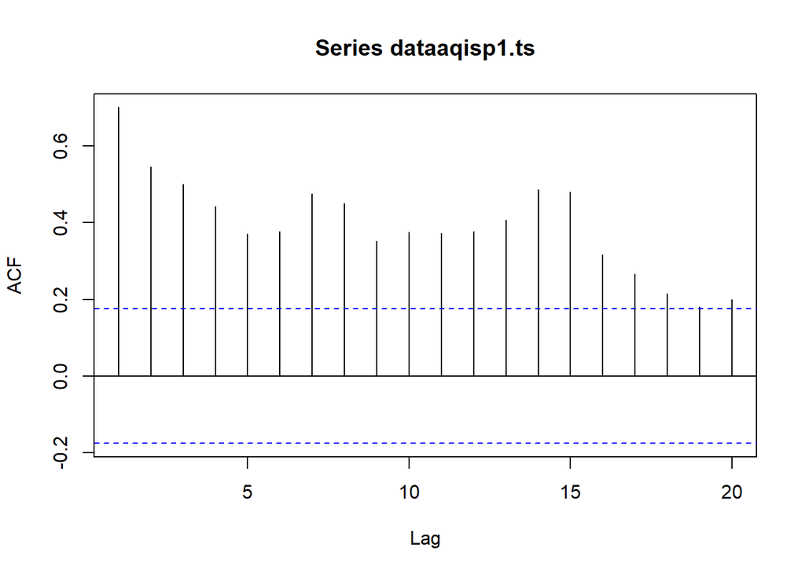

```r
acf(dataaqisp1.ts)
```

```r
tseries::adf.test(dataaqisp1.ts)
```

```
##
##  Augmented Dickey-Fuller Test
##
## data:  dataaqisp1.ts
## Dickey-Fuller = -5.271, Lag order = 4, p-value = 0.01
## alternative hypothesis: stationary
```

Secara plot ACF, data masih cenderung menurun perlahan membentuk pola tails off yang mengindikasikan data belum stasioner, tetapi berdasarkan uji ADF, didapat p value < 0.05 yang artinya data sudah stasioner dalam rataan

### Stasioneritas Ragam

```r
bcsp1 <- boxcox(
  dataaqisp1.ts ~ dataaqi$periode,
  lambda = seq(-1, 4, by = 0.01)
)
```

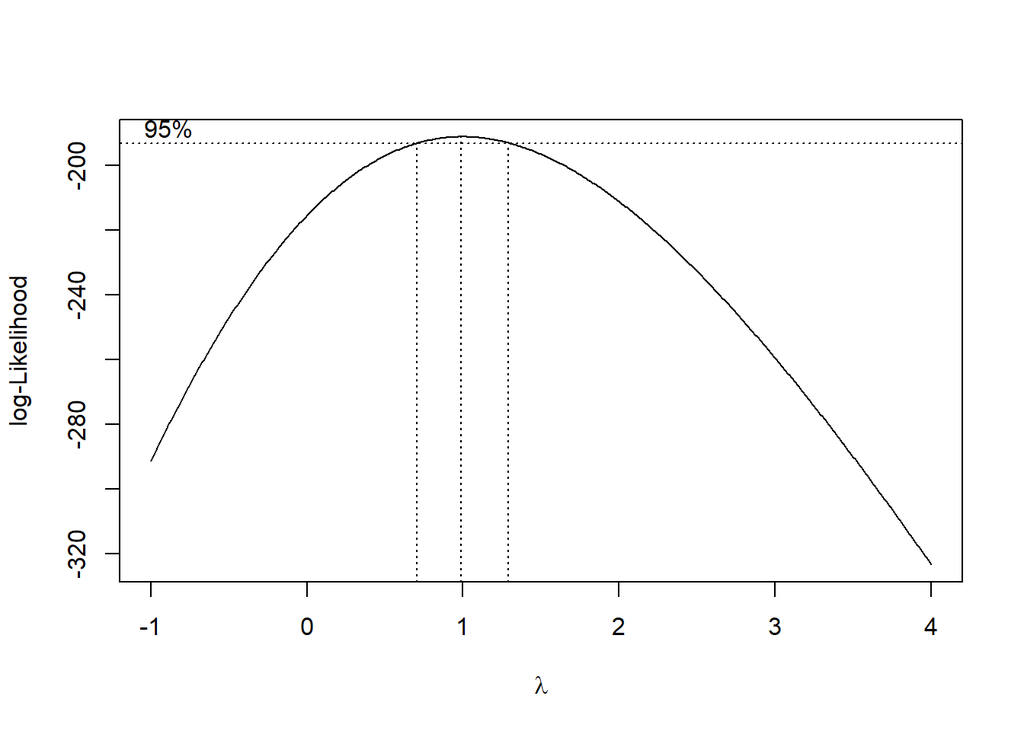

```r
lambdasp1 <- bcsp1$x[which.max(bcsp1$y)]
lambdasp1
```

```
## [1] 0.99
```

```r
# Selang kepercayaan 95% untuk lambda
ci_lambdasp1 <- bcsp1$x[bcsp1$y > max(bcsp1$y) - 0.5 * qchisq(0.95, 1)]

# Batas bawah dan batas atas
ci_lowersp1 <- min(ci_lambdasp1)
ci_uppersp1 <- max(ci_lambdasp1)

c(Batas_Bawah = ci_lowersp1, Batas_Atas = ci_uppersp1)
```

```
## Batas_Bawah  Batas_Atas
##        0.71        1.29
```

Setelah transformasi, hasil uji Box–Cox menunjukkan bahwa nilai λ optimum adalah 0.99 dengan interval kepercayaan 95% sebesar (0,71–1,29). Karena selang tersebut memuat nilai λ = 1, maka dapat disimpulkan bahwa data sudah stasioner dalam ragam.

## Skenario Penanganan 2

### Differencing

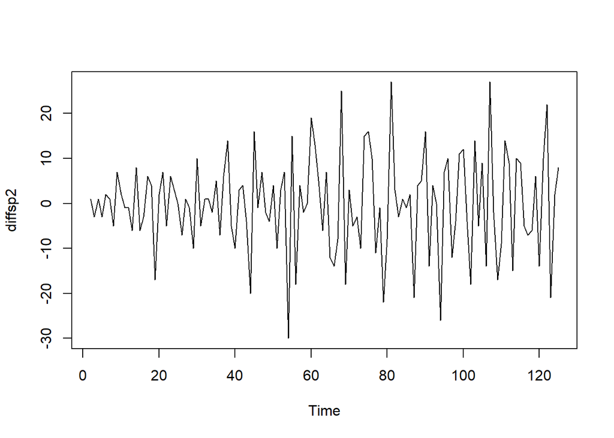

```r
diffsp2<-diff(dataaqi.ts,differences = 1)
ts.plot(diffsp2)
```

Setelah didifferencing sekali, terlihat data sudah bergerak pada nilai tengah/rataan yang konstan. Secara eksploratif, data ini seharusnya sudah stasioner dalam rataan.

### Transformasi

Sebelum ditransformasi box-cox, data perlu “digeser” karena box-cox mengharuskan data positif, sehingga seluruh amatan nilainya akan diubah menjadi: $y* = y - min(y) + 1$

```r
afterdiffsp2<-diffsp2-min(diffsp2)+1
```

```r
bcsp2 <- boxcox(
  afterdiffsp2 ~ dataaqi$periode[-max(dataaqi$periode)],
  lambda = seq(-1, 4, by = 0.01)
)
```

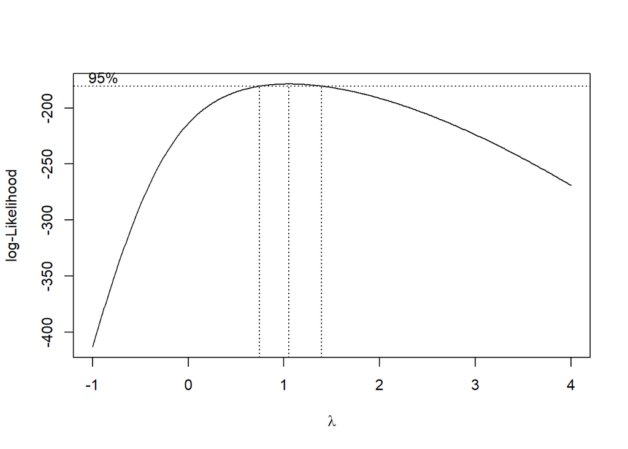

```r
lambdasp2 <- bcsp2$x[which.max(bcsp2$y)]
lambdasp2
```

```
## [1] 1.05
```

```r
# Selang kepercayaan 95% untuk lambda
ci_lambdasp2 <- bcsp2$x[bcsp2$y > max(bcsp2$y) - 0.5 * qchisq(0.95, 1)]

# Batas bawah dan batas atas
ci_lowersp2 <- min(ci_lambdasp2)
ci_uppersp2 <- max(ci_lambdasp2)

c(Batas_Bawah = ci_lowersp2, Batas_Atas = ci_uppersp2)
```

```
## Batas_Bawah  Batas_Atas
##        0.75        1.39
```

Hasil uji Box–Cox menunjukkan bahwa nilai λ optimum adalah 1.05 dengan interval kepercayaan 95% sebesar (0,75–1,39). Karena selang tersebut memuat nilai λ = 1, maka dapat disimpulkan bahwa data sudah stasioner dalam ragam, sehingga tidak perlu transformasi lagi.

### Stasioneritas Rataan

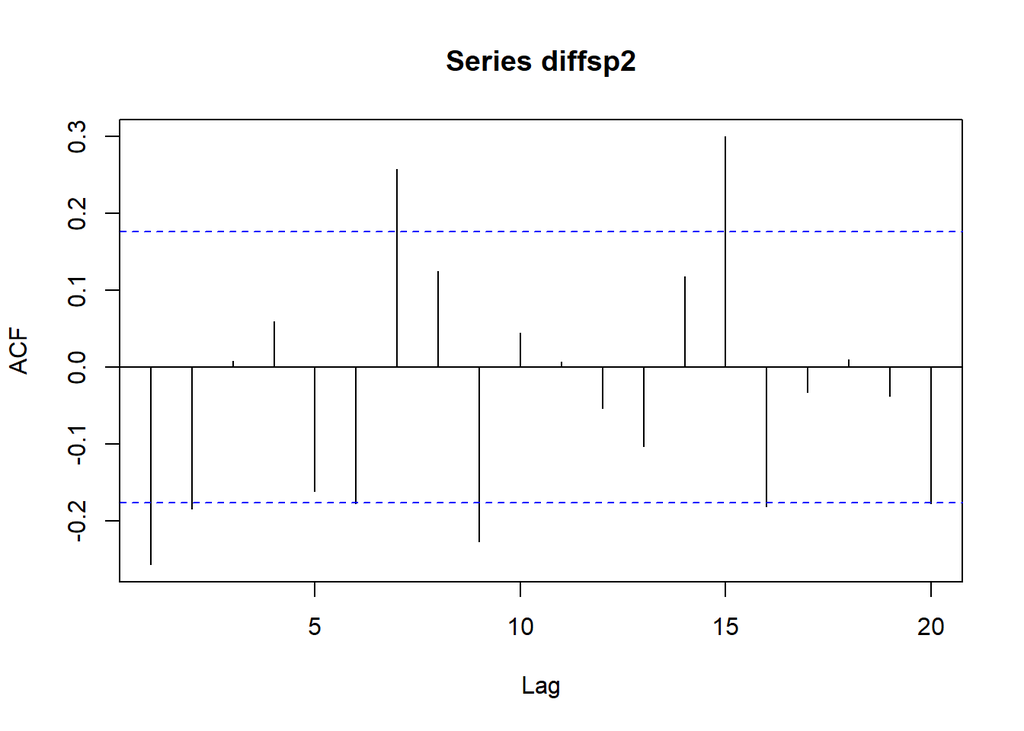

```r
acf(diffsp2)
```

```r
tseries::adf.test(diffsp2)
```

```
##
##  Augmented Dickey-Fuller Test
##
## data:  diffsp2
## Dickey-Fuller = -7.2238, Lag order = 4, p-value = 0.01
## alternative hypothesis: stationary
```

Pada plot ACF, terlihat pola yang langsung cuts off di lag 3, menandakan data sudah stasioner dalam rataan. Begitu pula dengan uji ADF yang signifikan pada taraf nyata 95%.

## Skenario Penanganan 3

### Transformasi

Karena kita sudah punya hasil sebelumnya, artinya data sudah stasioner dalam ragam, jadi langsung dilanjutkan ke tahap differencing menggunakan data tersebut.

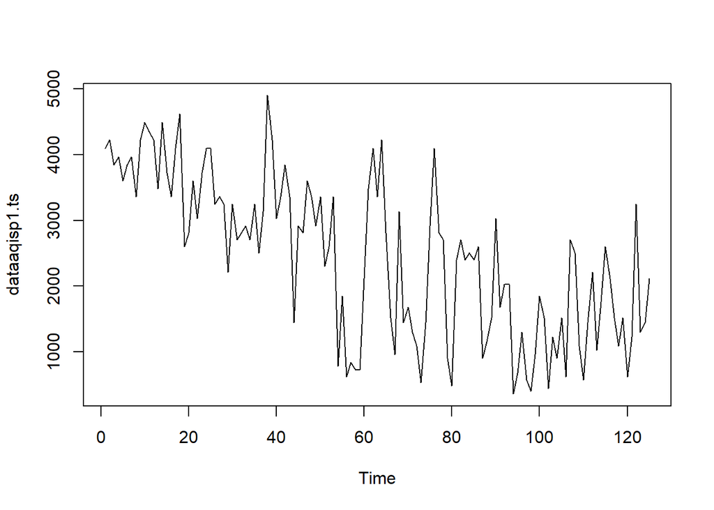

```r
ts.plot(dataaqisp1.ts)
```

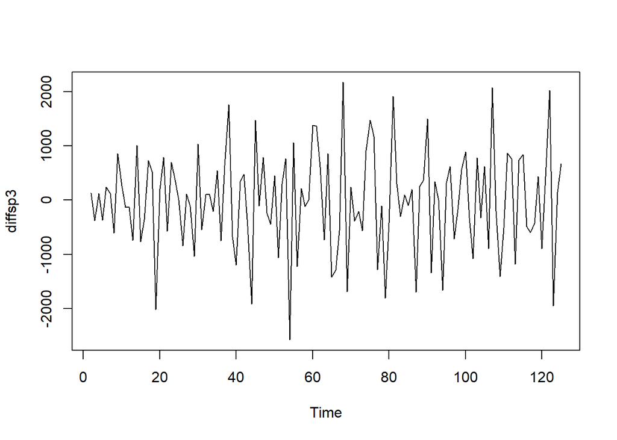

```r
diffsp3<-diff(dataaqisp1.ts,differences = 1)
ts.plot(diffsp3)
```

### Stasioneritas Rataan

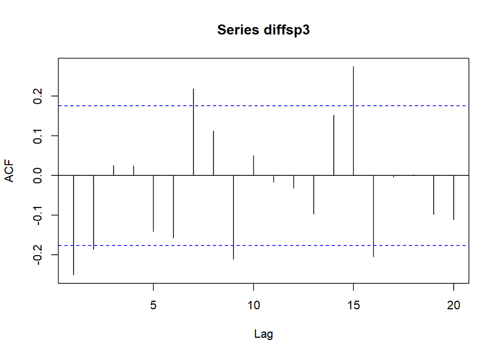

```r
acf(diffsp3)
```

```r
tseries::adf.test(diffsp3)
```

```
##
##  Augmented Dickey-Fuller Test
##
## data:  diffsp3
## Dickey-Fuller = -7.1739, Lag order = 4, p-value = 0.01
## alternative hypothesis: stationary
```

Pada plot ACF, terlihat pola yang langsung cuts off di lag 3, menandakan data stasioner dalam rataan. Begitu pula dengan uji ADF yang signifikan pada taraf nyata 95%.

# Kesimpulan

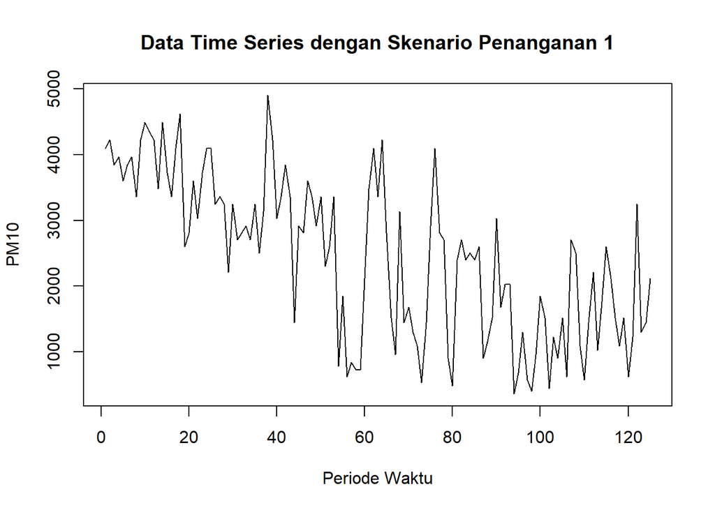

```r
ts.plot(dataaqisp1.ts,main="Data Time Series dengan Skenario Penanganan 1",ylab="PM10",xlab="Periode Waktu")
```

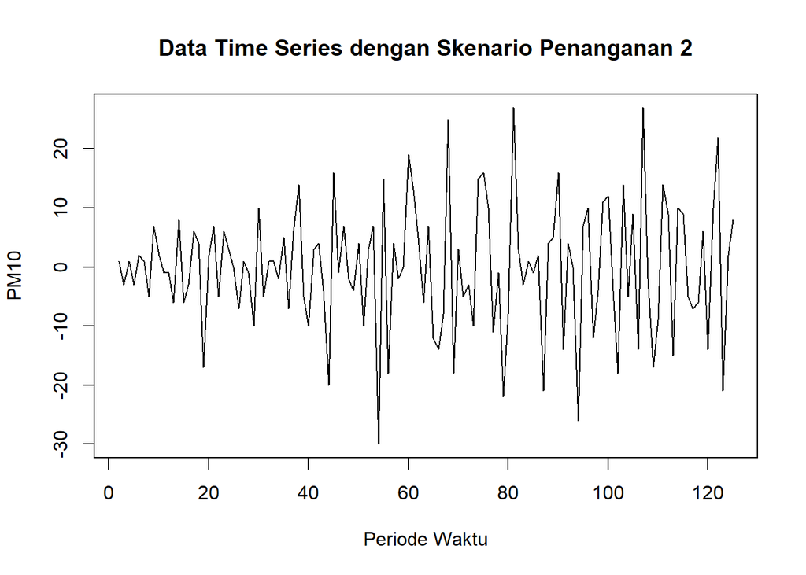

```r
ts.plot(diffsp2,main="Data Time Series dengan Skenario Penanganan 2",ylab="PM10",xlab="Periode Waktu")
```

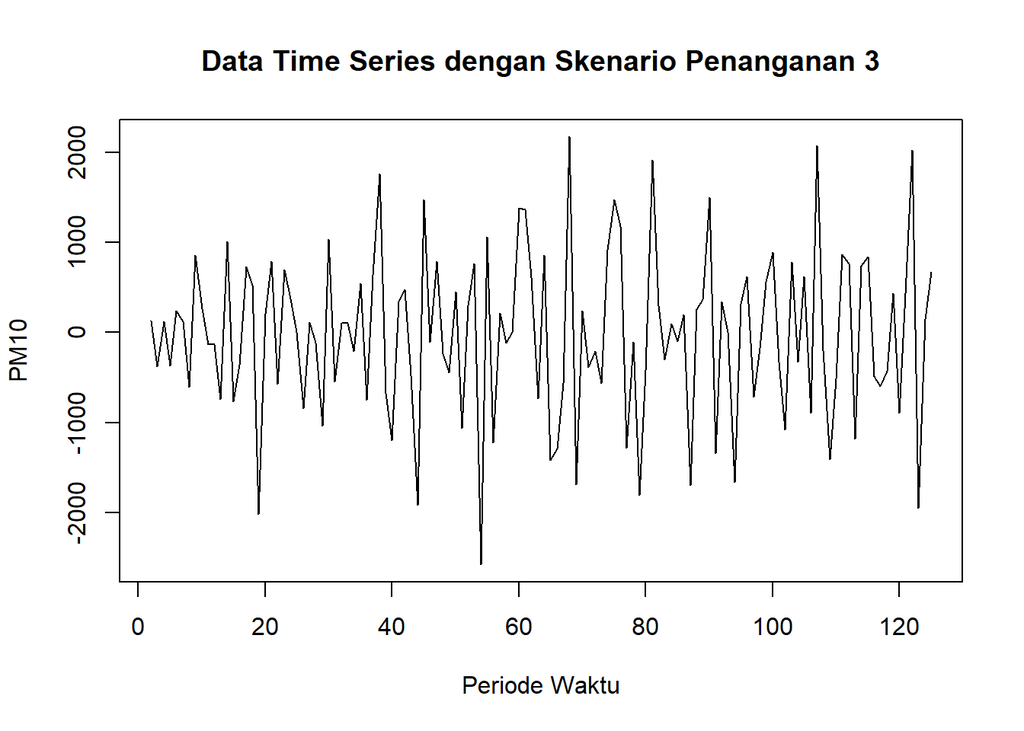

```r
ts.plot(diffsp3,main="Data Time Series dengan Skenario Penanganan 3",ylab="PM10",xlab="Periode Waktu")
```

Dari ketiga skenario diperoleh hasil ketiganya sudah stasioner dalam rataan dan ragam. Namun, secara plot time seriesnya, penanganan tanpa diferencing menghasilkan pola data yang cenderung memiliki tren meskipun uji ADF menunjukkan data stasioner